# First Questions

# Long, yes, but is it any good?

We finally turn to the second set of questions that got us started. Are longer movies considered to be better movies?

Let's start by plotting the average score minute by minute.

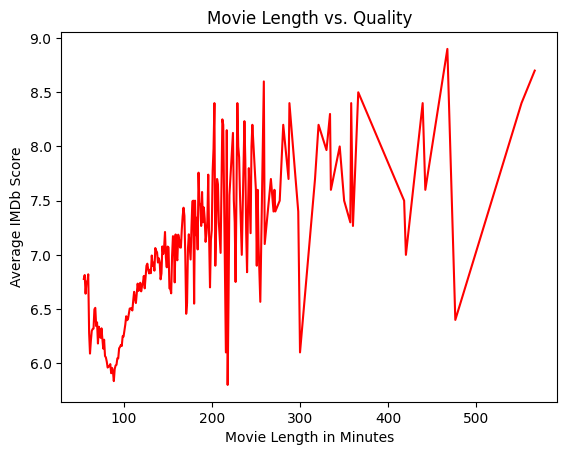

```python
minValues = recordDF.sort_values(by="Minutes")
groupMinValues = minValues.groupby(by="Minutes", as_index = False)
minScores = groupMinValues.Score.mean()

figure()
plot(minScores.Minutes, minScores.Score, 'r')
ylabel('Average IMDb Score')
xlabel('Movie Length in Minutes')
title('Movie Length vs. Quality')
show()
```

Although there are some visible trends, once the movie length goes very far over two hours (120 minutes), the chart looks fairly chaotic. There are relatively few such long movies, so let's see what a chart would look like with only films of less than three hours.

[figure not shown]

```python
shortMinValues = minValues.drop(minValues[minValues['Minutes'] > 180].index)
groupMinValues = shortMinValues.groupby(by="Minutes", as_index = False)
minScores = groupMinValues.Score.mean()

figure()
plot(minScores.Minutes, minScores.Score, 'r')
ylabel('Average IMDb Score')
xlabel('Movie Length in Minutes')
title('Movie Length vs. Quality')
show()
```

That looks like a strong signal that the lowest quality scores are for movies that run a bit less than 90 minutes, but that the quality scores improve for longer movies with a correlation to their extra length. Let's explore just a few genres, continuing to discard longer movies, and see if they have similar trends.

[figure not shown]

```python
#comDF = recordDF[recordDF['Comedy'] == 1]
shortCom = comDF.drop(comDF[comDF['Minutes'] > 180].index)
comValues = shortCom.groupby(by="Minutes", as_index = False)
comScores = comValues.Score.mean()
figure()
plot(comScores.Minutes, comScores.Score, 'r')
ylabel('Average IMDb Score')
xlabel('Movie Length in Minutes')
title('Comedy Movie Length vs. Quality')
show()
```

The curve is very similar for Comedy movies, with a minimum from 80 to 90 minutes, then a rising trend to over 120 minutes. After two hours, the chart's jagged peaks reflect the relative scarcity of Comedy movies with those running times.

[figure not shown]

```python
#fanDF = recordDF[recordDF['Fantasy'] == 1]
shortFan = fanDF.drop(fanDF[fanDF['Minutes'] > 180].index)
fanValues = shortFan.groupby(by="Minutes", as_index = False)
fanScores = fanValues.Score.mean()
figure()
plot(fanScores.Minutes, fanScores.Score, 'r')
ylabel('Average IMDb Score')
xlabel('Movie Length in Minutes')
title('Fantasy Movie Length vs. Quality')
show()
```

[figure not shown]

```python
#horDF = recordDF[recordDF['Horror'] == 1]
shortHor = horDF.drop(horDF[horDF['Minutes'] > 180].index)
horValues = shortHor.groupby(by="Minutes", as_index = False)
horScores = horValues.Score.mean()
figure()
plot(horScores.Minutes, horScores.Score, 'r')
ylabel('Average IMDb Score')
xlabel('Movie Length in Minutes')
title('Horror Movie Length vs. Quality')
show()
```

[figure not shown]

```python
#aniDF = recordDF[recordDF['Animation'] == 1]
shortAni = aniDF.drop(aniDF[aniDF['Minutes'] > 180].index)
aniValues = shortAni.groupby(by="Minutes", as_index = False)
aniScores = aniValues.Score.mean()
figure()
plot(aniScores.Minutes, aniScores.Score, 'r')
ylabel('Average IMDb Score')
xlabel('Movie Length in Minutes')
title('Animation Movie Length vs. Quality')
show()
```

# What about popularity?

Bearing in mind that **Correlation is not causation!**, it's time to move on the the final question:

Is there a movie length that is correlated with optimal movie popularity, based on number of “voters”?

Since the IMDb web site launched in 1993, I would expect that popularity is going to be strongly correlated with the age of a movie. Going all the way back to the "Change in Movie Length" chart, we see that the average film length has decreased during that period. Therefore, as it affects popularity, age and length should be relatively independent.

To try to smooth out the movie length values, let's split the dataframe into 20 sets from the shortest to the longest.

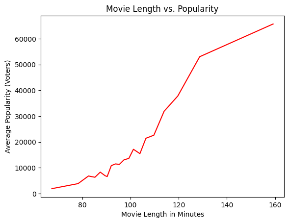

```python
# We already have the dataframe sorted by length
#minValues = recordDF.sort_values(by="Minutes")
minSize = minValues.shape[0]
chunkSize = int(minSize / 20)

# Now split the dataframe into a list of 20 equal-sized chunks
chunkDF = [minValues[i:i + chunkSize] for i in range(0, voterSize, chunkSize)]

# Create a dataframe of chunk averages
avgMinutes = []
avgVoters = []
for i in range (0, 20):
    avgMinutes.append(chunkDF[i].Minutes.mean())
    avgVoters.append(chunkDF[i].Voters.mean())
minVoters = pd.DataFrame({'Minutes': avgMinutes, 'Voters': avgVoters})

figure()
plot(minVoters.Minutes, minVoters.Voters, 'r')
ylabel('Average Popularity (Voters)')
xlabel('Movie Length in Minutes')
title('Movie Length vs. Popularity')
show()
```

Adding more data points to the curve reveals the variation between pockets of movie length values.

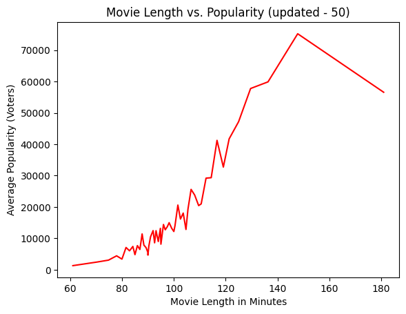

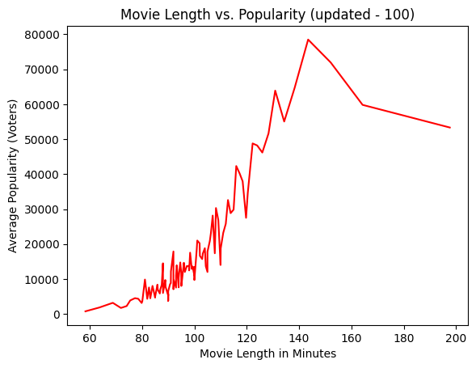

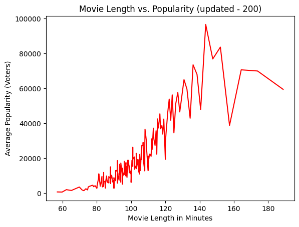

```python
chunk50Size = int(minSize / 50)

# Now split the dataframe into a list of 50 equal-sized chunks
chunk50DF = [minValues[i:i + chunk50Size] for i in range(0, voterSize, chunk50Size)]

# Create a dataframe of chunk averages
avgMinutes = []
avgVoters = []
for i in range (0, 50):
    avgMinutes.append(chunk50DF[i].Minutes.mean())
    avgVoters.append(chunk50DF[i].Voters.mean())
minVoters = pd.DataFrame({'Minutes': avgMinutes, 'Voters': avgVoters})

figure()
plot(minVoters.Minutes, minVoters.Voters, 'r')
ylabel('Average Popularity (Voters)')
xlabel('Movie Length in Minutes')
title('Movie Length vs. Popularity (updated - 50)')
show()


chunk100Size = int(minSize / 100)

# Now split the dataframe into a list of 100 equal-sized chunks
chunk100DF = [minValues[i:i + chunk100Size] for i in range(0, voterSize, chunk100Size)]

# Create a dataframe of chunk averages
avgMinutes = []
avgVoters = []
for i in range (0, 100):
    avgMinutes.append(chunk100DF[i].Minutes.mean())
    avgVoters.append(chunk100DF[i].Voters.mean())
minVoters = pd.DataFrame({'Minutes': avgMinutes, 'Voters': avgVoters})

figure()
plot(minVoters.Minutes, minVoters.Voters, 'r')
ylabel('Average Popularity (Voters)')
xlabel('Movie Length in Minutes')
title('Movie Length vs. Popularity (updated - 100)')
show()

chunk200Size = int(minSize / 200)

# Now split the dataframe into a list of 200 equal-sized chunks
chunk200DF = [minValues[i:i + chunk200Size] for i in range(0, voterSize, chunk200Size)]

# Create a dataframe of chunk averages
avgMinutes = []
avgVoters = []
for i in range (0, 200):
    avgMinutes.append(chunk200DF[i].Minutes.mean())
    avgVoters.append(chunk200DF[i].Voters.mean())
minVoters = pd.DataFrame({'Minutes': avgMinutes, 'Voters': avgVoters})

figure()
plot(minVoters.Minutes, minVoters.Voters, 'r')
ylabel('Average Popularity (Voters)')
xlabel('Movie Length in Minutes')
title('Movie Length vs. Popularity (updated - 200)')
show()
```

I believe that the smallest number of chunks better avoids overfitting this data. Using those broad samples, the correlation between longer movies and increased popularity shows no limit. But even with 50 chunks, the added granularity points to a peak of popularity for movies around 145 minutes long. And what's the length of 2024's most popular movie, "Deadpool & Wolverine"? 128 minutes.

# Summary

Every question has been answered.

The average movie length gradually increased from 1940 to 2000, then declined. That varies by genre: Comedy film length have slowly declined since 1962. Some genres, such as Adventure and Fantasy, held relatively steady to the end of the sampling period in 2021.

Comparing movie running times to popularity (number of IMDb users who rated a movie), it is clear that longer times are correlated with higher popularity. Some evidence suggests that trend peaks after 140 minutes, but the relative lack of data makes it hard to verify.

# Areas for Improvement

If I had to start this project from scratch, I would restrict my data set to the era after silent movies had faded away, roughly 1930 to present. My data exploration might have gone faster, with less duplicated effort, if I had examined the outliers at the start, keeping "Shoah" while removing the stitched-together serials and Andy Warhol's weird 1960s experiments.